# T1D analysis vaginal microbiome

Alexandra Jazmin Roth Schulze

2024-01-14

#Vaginal microbiome

##Description

For the complete analysis of bacterial and fungal components of the microbiome, pregnant women with T1D (n=161) and without T1D (n=150) each provided a vaginal swab sample in the third trimester of pregnancy; 11 with T1D and 10 without T1D provided samples in two different pregnancies and one without T1D provided a sample in three different pregnancies.

The current bacterial analysis was performed on a total of 310 samples:

T1D: 160 samples

Non-T1D: 150 samples

The Sample distribution of the vaginal microbiome between women with and without T1D:

| Var1 | Freq |
| --- | --- |
| Non-T1D | 150 |
| T1D | 160 |

All the models for the microbiome were adjusted for SeqRun batch effect and mother ID as random effects and parity and BMI as fixed effects because we know from the literature that those have an important effect on the vaginal microbiome.

##Alpha diversity

glmer.nb was used for richness because the data distributes like a negative binomial.

Blue: No T1D; Red: T1D.

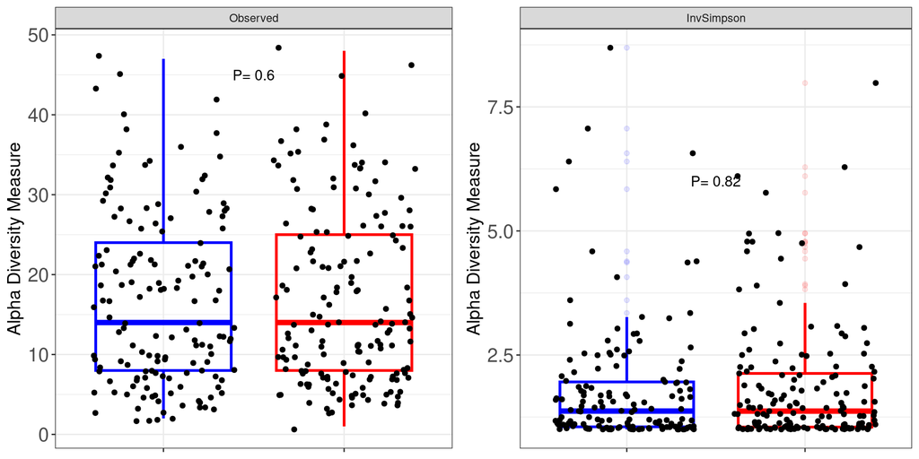

##Beta diversity

T1D status

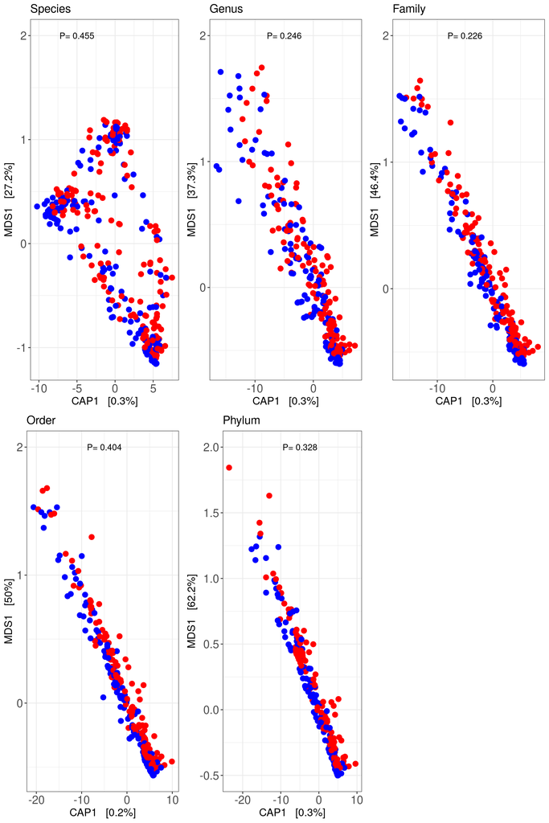

###Beta diversity HLA

##Differential abundance analysis

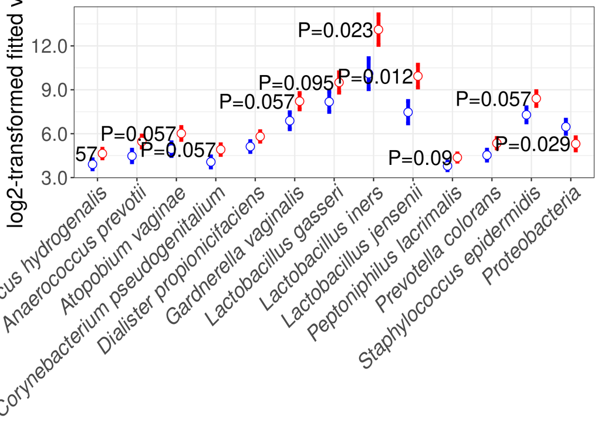

###Differential abundance HLA

|  | logFC | AveExpr | t | P.Value | adj.P.Val | B | T1DHLANonT1DGroup3o4 | T1DHLAT1DGroup3o4 | T1DHLANonT1DGroup3o4 | T1DHLAT1DGroup3o4 |
| --- | --- | --- | --- | --- | --- | --- | --- | --- | --- | --- |
| Lactobacillus_iners | -4.016015 | 10.819447 | -3.208392 | 0.0014760 | 0.0487096 | -1.250439 | 9.371395 | 13.387410 | 1.2479776 | 1.2496137 |
| Lactobacillus_jensenii | -2.468008 | 7.976362 | -2.944102 | 0.0034866 | 0.0490752 | -2.207214 | 8.152728 | 10.620736 | 0.8541977 | 0.8172439 |
| Staphylococcus_epidermidis* | -1.748086 | 7.054813 | -2.863905 | 0.0044614 | 0.0490752 | -2.488329 | 7.428232 | 9.176318 | 0.6259400 | 0.5904333 |
| Lactobacillus_crispatus | -2.169150 | 13.544905 | -2.441723 | 0.0151595 | 0.0817019 | -3.343911 | 12.761592 | 14.930742 | 0.9269766 | 0.8391019 |
| Lactobacillus_reuteri* | -1.491115 | 6.404200 | -2.444586 | 0.0150420 | 0.0817019 | -3.598234 | 5.939186 | 7.430301 | 0.6235340 | 0.5923560 |
| Anaerococcus_prevotii* | -1.287363 | 5.001156 | -2.404223 | 0.0167832 | 0.0817019 | -3.746986 | 5.013472 | 6.300835 | 0.5510502 | 0.5156112 |
| Prevotella_corporis | -1.269250 | 4.877466 | -2.392086 | 0.0173307 | 0.0817019 | -3.781615 | 5.023560 | 6.292810 | 0.5446403 | 0.5126446 |

|  | logFC | AveExpr | t | P.Value | adj.P.Val | B | T1DHLANonT1DDRXX | T1DHLAT1DDRXX | T1DHLANonT1DDRXX | T1DHLAT1DDRXX |
| --- | --- | --- | --- | --- | --- | --- | --- | --- | --- | --- |
| Peptoniphilus_duerdenii | 2.833123 | 4.487427 | 3.588846 | 0.0003849 | 0.0127033 | -0.0926649 | 5.577928 | 2.744805 | 0.4907977 | 0.7488162 |
| Corynebacterium_tuberculostearicum* | 3.135364 | 5.892946 | 3.286577 | 0.0011270 | 0.0129481 | -1.0193665 | 6.842803 | 3.707439 | 0.5871097 | 0.9078275 |
| Lactobacillus_reuteri* | 3.611768 | 6.404200 | 3.273881 | 0.0011771 | 0.0129481 | -1.0421668 | 7.344434 | 3.732666 | 0.7057167 | 1.0363866 |
| Prevotella_corporis | 2.893870 | 4.877466 | 3.047044 | 0.0025038 | 0.0191050 | -1.7360898 | 6.239857 | 3.345987 | 0.5849988 | 0.9035283 |
| Anaerococcus_prevotii* | 2.857266 | 5.001156 | 3.002181 | 0.0028947 | 0.0191050 | -1.8618761 | 6.065311 | 3.208045 | 0.5843255 | 0.9063419 |
| Corynebacterium_pseudogenitalium | 2.536287 | 4.684743 | 2.859796 | 0.0045217 | 0.0248694 | -2.2491128 | 5.618846 | 3.082559 | 0.5425205 | 0.8455248 |
| Staphylococcus_epidermidis* | 3.056546 | 7.054813 | 2.786661 | 0.0056439 | 0.0266070 | -2.3722885 | 8.666753 | 5.610207 | 0.6922129 | 1.0352885 |
| Corynebacterium_sundsvallense* | 2.544513 | 4.774376 | 2.625443 | 0.0090754 | 0.0374359 | -2.8465765 | 5.779277 | 3.234764 | 0.5962537 | 0.9223730 |
| Finegoldia | 2.430633 | 5.560589 | 2.574758 | 0.0104866 | 0.0384510 | -2.9424695 | 6.485273 | 4.054640 | 0.5696852 | 0.9036322 |
| Dialister_propionicifaciens | 2.099509 | 5.650239 | 2.362882 | 0.0187323 | 0.0581257 | -3.4256756 | 6.268554 | 4.169045 | 0.5304917 | 0.8531009 |
| Lawsonella_clevelandensis | 1.807086 | 4.508047 | 2.350276 | 0.0193752 | 0.0581257 | -3.4931272 | 4.916214 | 3.109129 | 0.4672547 | 0.7344792 |
| Varibaculum_cambriense* | 1.787384 | 4.610810 | 2.263572 | 0.0242796 | 0.0667688 | -3.6721436 | 5.294136 | 3.506752 | 0.4767889 | 0.7557177 |

|  | logFC | AveExpr | t | P.Value | adj.P.Val | B | Mean | SE |
| --- | --- | --- | --- | --- | --- | --- | --- | --- |
| Lactobacillus | -1.636241 | 18.8586 | -2.958538 | 0.0033321 | 0.0633092 | -1.907488 | 17.94310 | 0.5691167 |
| 2 | -1.636241 | 18.8586 | -2.958538 | 0.0033321 | 0.0633092 | -1.907488 | 19.57935 | 0.5313415 |

|  | logFC | AveExpr | t | P.Value | adj.P.Val | B | T1DHLANonT1DGroup3o4 | T1DHLAT1DGroup3o4 | T1DHLANonT1DGroup3o4 | T1DHLAT1DGroup3o4 |
| --- | --- | --- | --- | --- | --- | --- | --- | --- | --- | --- |
| Lactobacillaceae | -2.400958 | 18.847275 | -3.67827 | 0.0002724 | 0.0043577 | 0.1409813 | 17.41187 | 19.812824 | 0.6799784 | 0.6256701 |
| Staphylococcaceae | -1.839131 | 6.986961 | -2.65534 | 0.0082909 | 0.0663275 | -2.8669986 | 5.97958 | 7.818711 | 0.7097202 | 0.6782256 |

|  | logFC | AveExpr | t | P.Value | adj.P.Val | B | Mean | SE |
| --- | --- | --- | --- | --- | --- | --- | --- | --- |
| Selenomonadales | 1.71237 | 8.526213 | 2.695571 | 0.0074033 | 0.0814359 | -2.528596 | 10.225089 | 0.6531815 |
| 2 | 1.71237 | 8.526213 | 2.695571 | 0.0074033 | 0.0814359 | -2.528596 | 8.512719 | 0.6084669 |

|  | logFC | AveExpr | t | P.Value | adj.P.Val | B | Mean | SE |
| --- | --- | --- | --- | --- | --- | --- | --- | --- |
| Bifidobacteriales | -4.237453 | 10.64549 | -2.945173 | 0.0034718 | 0.0381893 | -1.925763 | 9.607843 | 0.8720672 |
| 2 | -4.237453 | 10.64549 | -2.945173 | 0.0034718 | 0.0381893 | -1.925763 | 13.845296 | 1.3741951 |

|  | logFC | AveExpr | t | P.Value | adj.P.Val | B | T1DHLANonT1DGroup3o4 | T1DHLAT1DGroup3o4 | T1DHLANonT1DGroup3o4 | T1DHLAT1DGroup3o4 |
| --- | --- | --- | --- | --- | --- | --- | --- | --- | --- | --- |
| Actinobacteria | 2.130004 | 12.640758 | 2.794096 | 0.0055046 | 0.0275232 | -2.347337 | 12.658071 | 10.528067 | 0.7565296 | 0.7657787 |
| Bacteroidetes | 1.717041 | 10.874382 | 2.243550 | 0.0255157 | 0.0637891 | -3.599153 | 12.026312 | 10.309271 | 0.7850981 | 0.7414195 |
| Proteobacteria | 1.205828 | 5.956959 | 1.934258 | 0.0539250 | 0.0898750 | -4.248780 | 6.224359 | 5.018531 | 0.6398345 | 0.6035541 |

|  | logFC | AveExpr | t | P.Value | adj.P.Val | B | Mean | SE |
| --- | --- | --- | --- | --- | --- | --- | --- | --- |
| Actinobacteria | -3.602302 | 12.64076 | -2.937496 | 0.0035384 | 0.0176919 | -1.954789 | 11.32028 | 0.8674275 |
| 2 | -3.602302 | 12.64076 | -2.937496 | 0.0035384 | 0.0176919 | -1.954789 | 14.92258 | 1.1029947 |

#CSTs and Lactobacillus spp.

The vaginal microbiota in healthy women has been extensively characterised. It is generally dominated by lactobacilli and can be classified into five community state types, four of which are dominated by a single lactobacillus species (Ravel et al, 2011). The community state types are:

**CST I**, which is dominated by *Lactobacillus crispatus*

**CST II**, which is dominated by *Lactobacillus gasseri*

**CST III**, dominated by *Lactobacillus iners*

**CST V**, which is dominated by *Lactobacillus jensenii*

**CST IV**, the fifth type which is different in that it is characterised by a **lack** of *lactobacillus* species and an increase in the presence of anaerobic bacteria such as *Prevotella, Atopobium vaginae, Gardnerella vaginalis, Streptococcus, Dialister, Finegoldia, Mobiluncus, Sneathia, Parvimonas, Fastidiosipila, Peptoniphilus, Anaerococcus, Veillonella* and *Corynebacterium*.

CST IV is most often associated with BV (Ravel et al, 2014).

CST IV species were obtained from Ma and Li (2017), Quantifying the human vaginal community state types (CSTs) with the species specificity index. PeerJ 5:e3366; DOI 10.7717/peerj.3366

| Non-T1D | T1D |
| --- | --- |
| 150(48%) | 160(52%) |

###CST distribution between T1D and non-T1D

Using multinommial logistic regression to test differences in frequencies of CST among T1D status and parity. Here the response variable is CST (which has more than 2 levels and hence is a multinomial logistic regression) and the explanatory are T1D status and Parity.

|  | Non-T1D | T1D | All |
| --- | --- | --- | --- |
| CST-Bifido | 5(3%) | 8(5%) | 13(4%) |
| CSTI | 54(36%) | 69(43%) | 123(40%) |
| CSTII | 13(9%) | 6(4%) | 19(6%) |
| CSTIII | 37(25%) | 40(25%) | 77(25%) |
| CSTIV | 34(23%) | 31(19%) | 65(21%) |
| CSTV | 7(5%) | 6(4%) | 13(4%) |
| Total | NA | NA | NA |

|  | (Intercept) | T1Dstatus2T1D |
| --- | --- | --- |
| CSTI | 0.0000004 | 0.7071662 |
| CSTII | 0.0693947 | 0.0992299 |
| CSTIII | 0.0000266 | 0.5232718 |
| CSTIV | 0.0000628 | 0.3658659 |
| CSTV | 0.5655122 | 0.4333570 |

###CST distribution between T1D and non-T1D + parity

Where:

Non-T1D.0: Nulliparous women without T1D

Non-T1D.1: Multiparous women without T1D

T1D.0: Nulliparous women with T1D

T1D.1: Multiparous women with T1D

|  |  | Non-T1D |  |  | T1D |  |
| --- | --- | --- | --- | --- | --- | --- |
| Parity | NA | NA | NA | NA | NA | NA |
| CST-Bifido | 1(1%) | 4(5%) | 5(3%) | 3(4%) | 5(7%) | 8(5%) |
| CSTI | 42(62%) | 12(15%) | 54(36%) | 48(56%) | 21(28%) | 69(43%) |
| CSTII | 1(1%) | 12(15%) | 13(9%) | 1(1%) | 5(7%) | 6(4%) |
| CSTIII | 11(16%) | 26(32%) | 37(25%) | 17(20%) | 23(31%) | 40(25%) |
| CSTIV | 10(15%) | 24(29%) | 34(23%) | 14(16%) | 17(23%) | 31(19%) |
| CSTV | 3(4%) | 4(5%) | 7(5%) | 2(2%) | 4(5%) | 6(4%) |
| Total | NA | NA | NA | NA | NA | NA |

###CST distribution between T1D and non-T1D + BMI

Where:

Non-T1D.U: Underweight women without T1D

Non-T1D.N: Normal weight women without T1D

Non-T1D.Ov: Overweight women without T1D

Non-T1D.Ob: Obese women without T1D

T1D.U: Underweight women with T1D

T1D.N: Normal weight women with T1D

Non-T1D.Ov: Overweight women without T1D

Non-T1D.Ob: Obese women without T1D

|  |  |  | Non-T1D |  |  |  |  | T1D |  |  |
| --- | --- | --- | --- | --- | --- | --- | --- | --- | --- | --- |
| BMI | NA | NA | NA | NA | NA | NA | NA | NA | NA | NA |
| CST-Bifido | 3(4%) | 0(0%) | 2(6%) | 0(0%) | 5(3%) | 4(6%) | 3(7%) | 1(2%) | 0(0%) | 8(5%) |
| CSTI | 31(38%) | 9(30%) | 11(34%) | 0(0%) | 51(35%) | 33(49%) | 16(36%) | 18(43%) | 0(0%) | 67(43%) |
| CSTII | 7(9%) | 4(13%) | 2(6%) | 0(0%) | 13(9%) | 3(4%) | 2(4%) | 1(2%) | 0(0%) | 6(4%) |
| CSTIII | 23(28%) | 5(17%) | 8(25%) | 1(50%) | 37(26%) | 9(13%) | 14(31%) | 15(36%) | 2(67%) | 40(25%) |
| CSTIV | 14(17%) | 11(37%) | 7(22%) | 0(0%) | 32(22%) | 14(21%) | 9(20%) | 6(14%) | 1(33%) | 30(19%) |
| CSTV | 3(4%) | 1(3%) | 2(6%) | 1(50%) | 7(5%) | 4(6%) | 1(2%) | 1(2%) | 0(0%) | 6(4%) |
| Total | NA | NA | NA | NA | NA | NA | NA | NA | NA | NA |

Note: Others=CSTV

####Testing for differences in frequency of CSTs due to T1D status (BMI + Parity with interaction)

Using multinommial logistic regression to test differences in frequencies of CST among T1D status and BMI

Multinomial test T1D status with interactions

|  | (Intercept) | BMI | T1DstatusT1D | Parity1 | BMI:T1DstatusT1D | T1DstatusT1D:Parity1 |
| --- | --- | --- | --- | --- | --- | --- |
| CSTI | 0.6315400 | 0.3463441 | 0.6145071 | 0.0176520 | 0.3918037 | 0.2786193 |
| CSTII | 0.6427432 | 0.6005108 | 0.9706995 | 0.5369056 | 0.7117519 | 0.9450150 |
| CSTIII | 0.5136871 | 0.7879925 | 0.7687248 | 0.6221454 | 0.9566668 | 0.8029416 |
| CSTIV | 0.7109700 | 0.2074585 | 0.4509141 | 0.4899915 | 0.2974285 | 0.7532701 |
| CSTV | 0.9947822 | 0.7091354 | 0.9766710 | 0.3826120 | 0.6786795 | 0.4345864 |

###Lactobacillus spp. distribution between T1D and non-T1D + parity

The vaginal microbiomes of pregnant women with and without T1D is rich in total Lactobacillus spp, with ~70% of samples from either group being dominated by lactobacilli (>70%). Generally, nulliparous women have more prevalence/abundance of Lactobacillus,irrespective of T1D status and the difference is slightly larger within non-T1D women. This is consistent with the current differential abundance analysis in which we observed higher abundance of Lactobacillus in nulliparous than multiparous women irrespective of T1D status.

|  |  | Non-T1D |  |  | T1D |  |
| --- | --- | --- | --- | --- | --- | --- |
| Lactobacillus spp. | NA | NA | NA | NA | NA | NA |
| >70% | 50(78%) | 48(59%) | 98(68%) | 63(76%) | 48(65%) | 111(71%) |
| >80% | 47(73%) | 45(56%) | 92(63%) | 61(73%) | 42(57%) | 103(66%) |
| >90% | 41(64%) | 38(47%) | 79(54%) | 57(69%) | 39(53%) | 96(61%) |

###Lactobacillus spp. distribution between T1D and non-T1D + BMI

|  |  |  | Non-T1D |  |  |  | T1D |  |  | NA |
| --- | --- | --- | --- | --- | --- | --- | --- | --- | --- | --- |
| Lactobacillus spp. | NA | NA | NA | NA | NA | NA | NA | NA | NA | NA |
| >70% | 57(70%) | 18(60%) | 21(66%) | 2(100%) | 98(68%) | 47(70%) | 30(67%) | 32(76%) | 2(67%) | 111(71%) |
| >80% | 53(65%) | 17(57%) | 20(62%) | 2(100%) | 92(63%) | 45(67%) | 27(60%) | 29(69%) | 2(67%) | 103(66%) |
| >90% | 47(58%) | 13(43%) | 17(53%) | 2(100%) | 79(54%) | 40(60%) | 25(56%) | 29(69%) | 2(67%) | 96(61%) |

####Testing for differences in frequency of Lactobacillus dominated in T1D (+ Parity + BMI)

Binomial logistic regression to test if the distribution (presence/absence) of Lactobacillus at certain percentage is significantly different depending on T1D status. The response variable is presence/absence of Lactobacillus (one test for each category >70%, >80% and >90%) and the explanatory variables are T1Dstatus and parity.

*Lactobacillus abundance > L70*

|  | LR Chisq | Df | Pr(>Chisq) |
| --- | --- | --- | --- |
| Parity | 6.5431482 | 1 | 0.0105289 |
| T1Dstatus | 0.1442445 | 1 | 0.7040973 |
| BMI_Cat | 0.7437518 | 3 | 0.8628680 |
| Parity:T1Dstatus | 0.4401386 | 1 | 0.5070556 |
| T1Dstatus:BMI_Cat | 1.6782722 | 3 | 0.6417751 |

*Lactobacillus abundance > L80*

|  | LR Chisq | Df | Pr(>Chisq) |
| --- | --- | --- | --- |
| Parity | 8.8651510 | 1 | 0.0029067 |
| T1Dstatus | 0.0286227 | 1 | 0.8656530 |
| BMI_Cat | 0.9637145 | 3 | 0.8100310 |
| Parity:T1Dstatus | 0.0094695 | 1 | 0.9224792 |
| T1Dstatus:BMI_Cat | 1.4917542 | 3 | 0.6841748 |

*Lactobacillus abundance > L90*

|  | LR Chisq | Df | Pr(>Chisq) |
| --- | --- | --- | --- |
| Parity | 6.6927479 | 1 | 0.0096806 |
| T1Dstatus | 0.9435132 | 1 | 0.3313760 |
| BMI_Cat | 2.3009299 | 3 | 0.5123428 |
| Parity:T1Dstatus | 0.0027154 | 1 | 0.9584418 |
| T1Dstatus:BMI_Cat | 2.0891511 | 3 | 0.5541107 |

#Vaginal mycobiome

##Description

For analysing the vaginal microbiome of women with and without T1D, there are a total of 144 samples for which we have the GBS status. The samples are distributed between women with and without T1D as follows:

| Var1 | Freq |
| --- | --- |
| Non-T1D | 74 |
| T1D | 70 |

Since there are no mothers repeated for this dataset, we don’t need to take into account the effect of motherid in any of the analyses.

##Alpha diversity analysis

This analysis was done by subsampling the OTU table (features were categorised into OTUs based on the phylogenetic tree with threshold 0.03) each sample to 5000 sequences.

```
Analysis of Deviance Table (Type II tests)

Response: Observed
                 LR Chisq Df Pr(>Chisq)
BMI               1.83371  1     0.1757
t1dfactor         1.56996  1     0.2102
Parity            0.20840  1     0.6480
BMI:t1dfactor     0.00368  1     0.9516
t1dfactor:Parity  0.62389  1     0.4296
```

```
Likelihood ratio test

Model 1: Observed ~ BMI + Parity + t1dfactor
Model 2: Observed ~ BMI + t1dfactor
  #Df  LogLik Df  Chisq Pr(>Chisq)
1   5 -392.48
2   4 -392.58 -1 0.2085      0.648
```

```
Likelihood ratio test

Model 1: Observed ~ t1dfactor
Model 2: Observed ~ BMI + t1dfactor
  #Df  LogLik Df  Chisq Pr(>Chisq)
1   3 -393.79
2   4 -392.58  1 2.4092     0.1206
```

```
                    2.5 %   97.5 %
(Intercept)  1.6073066132 1.948252
t1dfactorT1D 0.0007885097 0.481504
```

```
Likelihood ratio test

Model 1: as.integer(InvSimpson * 1000) ~ BMI + t1dfactor
Model 2: as.integer(InvSimpson * 1000) ~ BMI + Parity + t1dfactor
  #Df  LogLik Df  Chisq Pr(>Chisq)
1   4 -1212.3
2   5 -1212.3  1 0.0113     0.9153
```

```
Likelihood ratio test

Model 1: as.integer(InvSimpson * 1000) ~ t1dfactor
Model 2: as.integer(InvSimpson * 1000) ~ BMI + t1dfactor
  #Df  LogLik Df  Chisq Pr(>Chisq)
1   3 -1212.7
2   4 -1212.3  1 0.7482      0.387
```

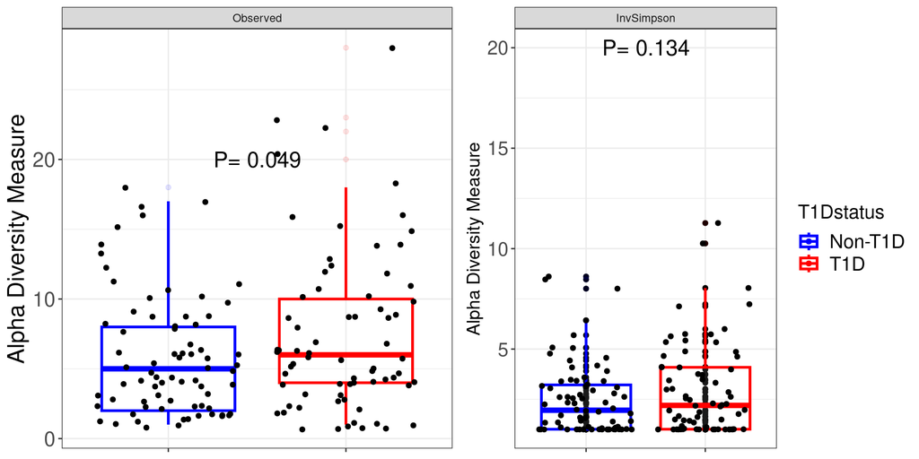

##Beta diversity analysis

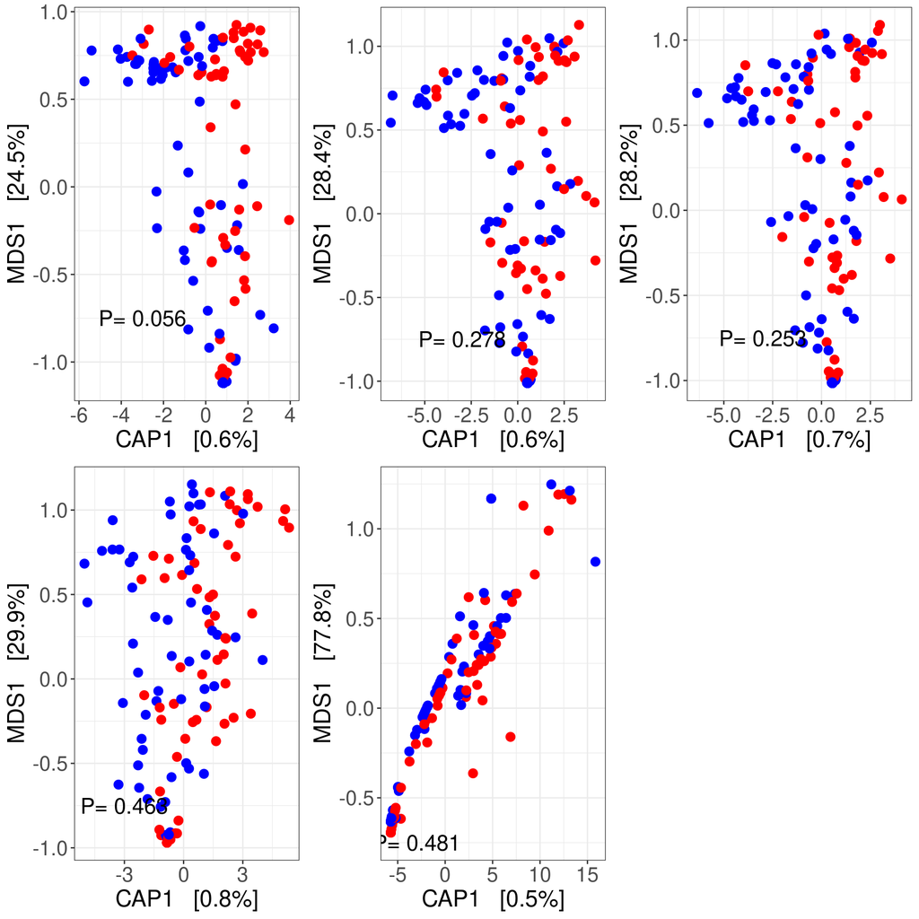

##Differential abundance (T1D status)

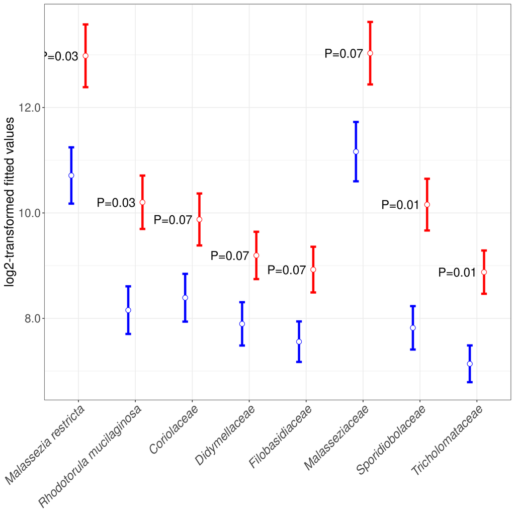

###Differential abundance HLA

|  | logFC | P.Value | adj.P.Val | MEAN:High | MEAN:Low | SE:High | SE:Low |
| --- | --- | --- | --- | --- | --- | --- | --- |
| Basidiomycota | -3.80359 | 0.0130758 | 0.0196137 | 12.62825 | 16.43184 | 1.741014 | 1.27489 |

###Composed figures (T1D status for manuscript)

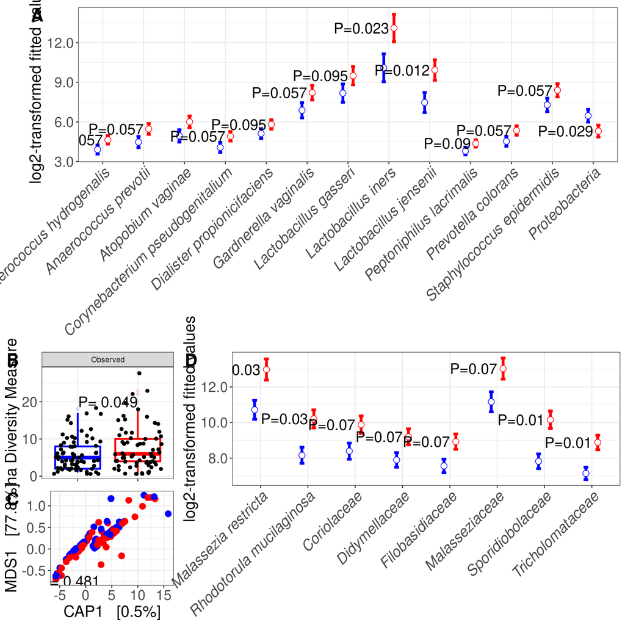